# Modeling tactical and memory-driven migration in dynamic environments

Sriya Potluri and Elie Gurarie  
March 2021

### Premise

To optimally forage in a dynamic environment, you need both **tactical** responses (adapting to local changes in resource gradients), and **strategic** responses (using memory to guide long-term decisions).

### Model

\[ {\frac{\partial u(x,t)}{\partial t}} = -\varepsilon {\frac{\partial^2 u(x,t)}{\partial x^2}} + \alpha \frac{\partial h(x,t)}{\partial x} + \sum_{i = 0}^n \beta_i \frac{\partial u(x, t - i\tau)}{\partial x} \]

- \( \epsilon \): diffusion, exploration / search
- \( \alpha \): taxis, resource following
- \( \beta_0 \): cohesion, tendency to stick to group
- \( \beta_1 \): memory, tendency to do what was done previous year

### Seasonal resource

\[ R(x,t, \theta) = \chi B(x/\chi, a(t, \theta), b(t, \theta)) \]

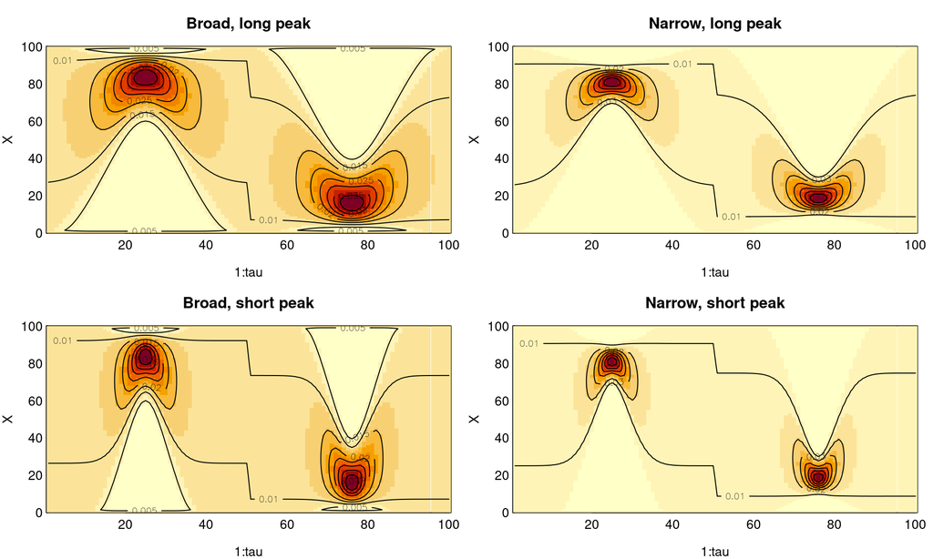

### Running the model

- R package `deSolve` and `ReacTran` - fluid transport pde solvers.
- Functions all in `memorymigration` GitHub project.
- SESYNC cluster
- server-based Rstudio

### Example run: with Memory and Sociality

\( \epsilon =20; \alpha = 200; \beta_0 = 250; \beta_1 = 250 \)

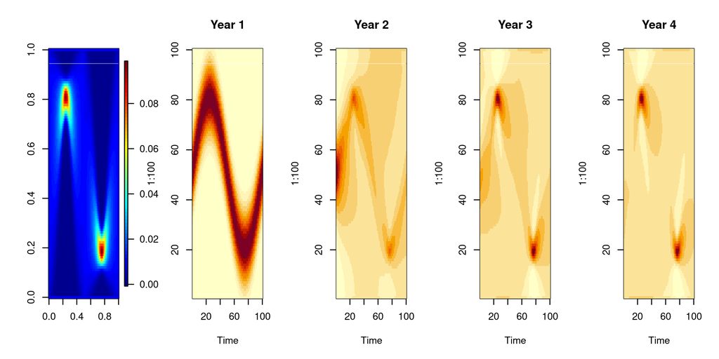

### Example run: no Sociality, only Memory

\( \epsilon =20; \alpha = 200; \beta_0 = 0; \beta_1 = 250 \)

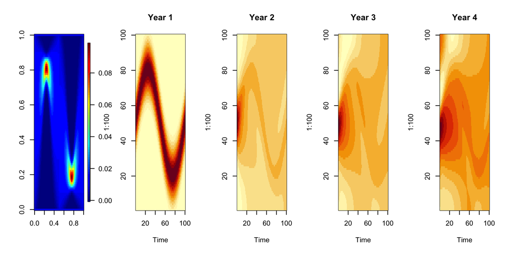

### Example run: no Memory, only Sociality

\( \epsilon =20; \alpha = 200; \beta_0 = 250; \beta_1 = 0 \)

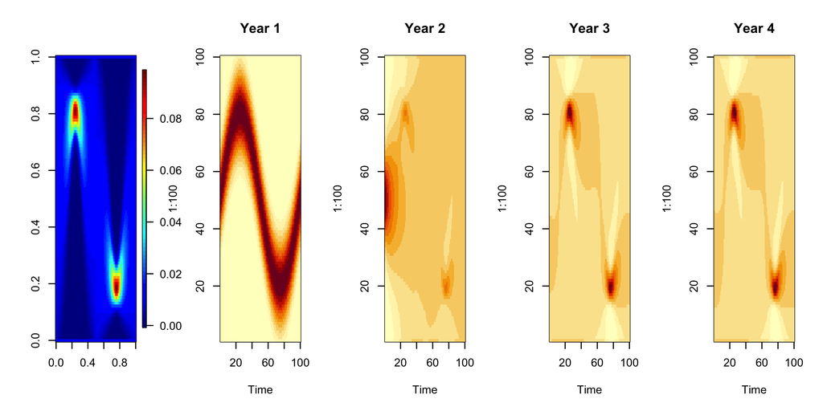

### Comparing Examples

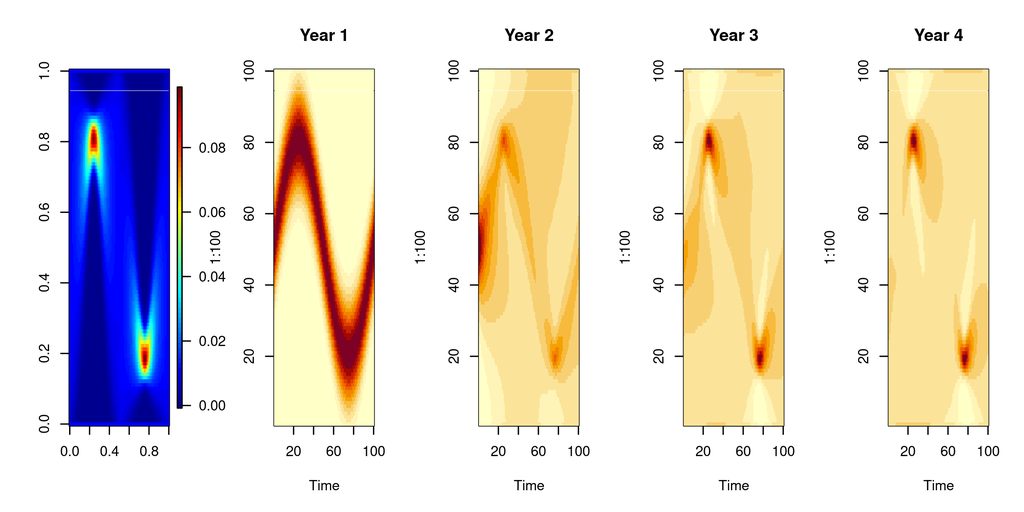

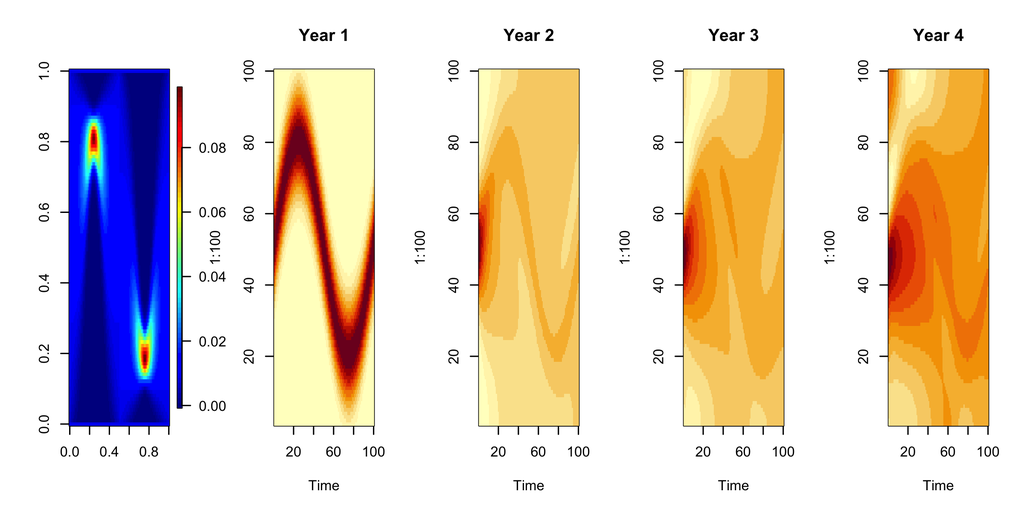

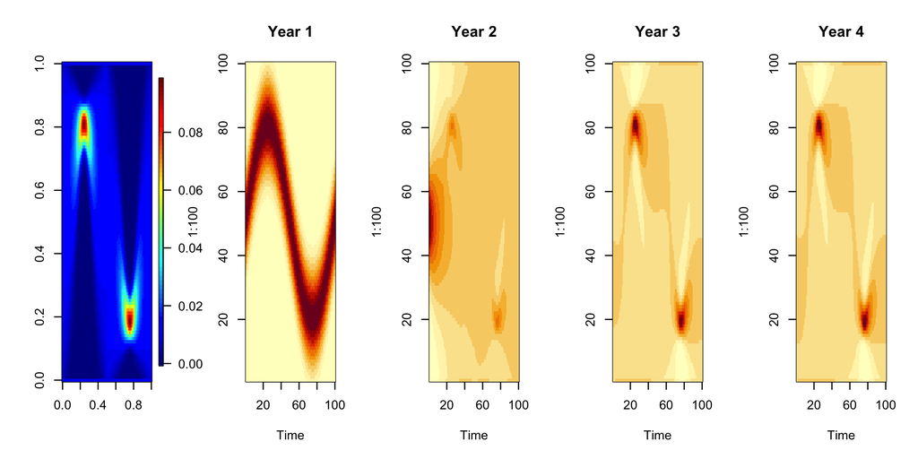

1. Memory and Sociality 2. Only Memory 3. Only Sociality

### Metrics

1. Social Cohesiveness
2. Foraging Efficiency
3. Migratoriness

### Metrics: Cohesiveness (problematic!)

\[ SC = 1-\frac{\sqrt{12} \, }{X_{max}}\overline{\sigma} \]

\[ \overline{\sigma} = {1\over \tau} \int \sigma_u(x,t) \,dt \] where \[ \sigma_u^2(t) = \int_D \left(x - \mu_u(t)\right)^2 \, u(x,t)\, dx \]

and \( \mu_u \) is the mean of \( u \) at time \( t \).

Definition: The mean standard deviation of the population across the equilibrium year

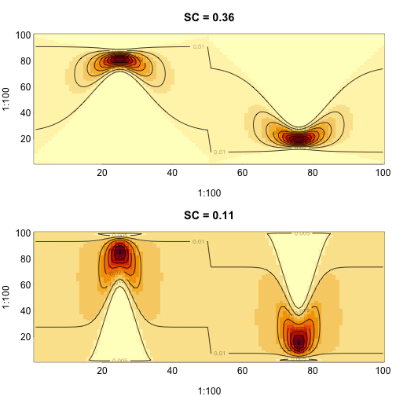

### Social Cohesiveness: Problem

For skewed of bimodal population distribution, standard deviation are a poor measure … \( \epsilon = 8; \alpha = 200; \beta_0 = 500; \beta_1 = 0 \)

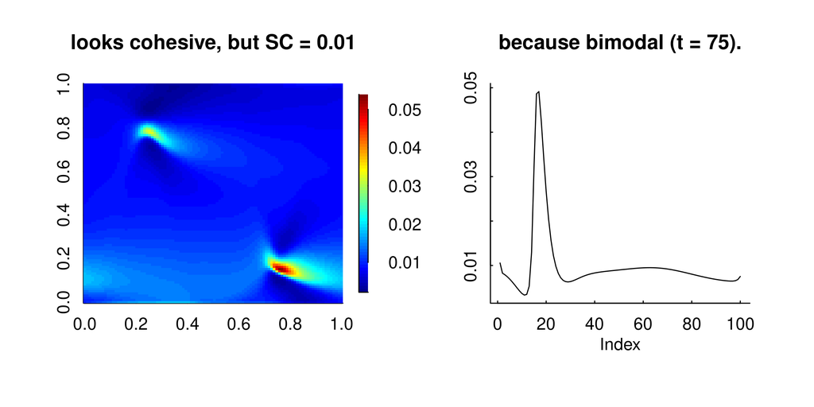

**Not sure how to deal with this …**

### Metrics: Foraging Efficiency

\[ FE = {1\over \tau} \int_{0}^\tau \int_{0}^{X_{max}} \sqrt{u(x,t) \, h(x,t)} \, dx\,dt \]

**Bhattacharyya Coefficient** quantifies similarity between two distributions.

\( \epsilon = 8; \alpha = 200; \beta_0 = 500; \beta_1 = 0 \)

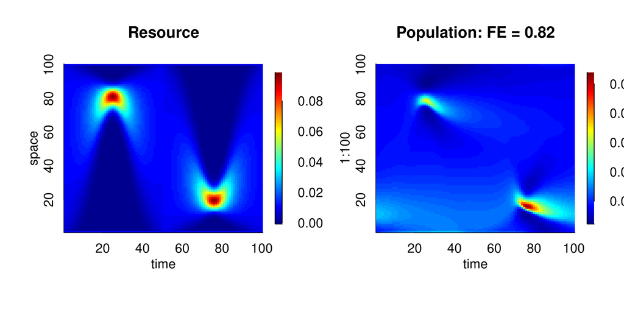

### Metrics: Foraging Efficiency - Issues

Seems to always be very high!

Also - assumes that there is some sort of space inhibition … the actually highest efficiency is when animals pile in at indefinitely high density at the location of highest resource availability.

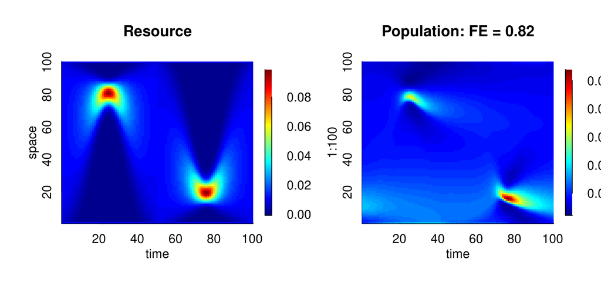

### Metrics: Migratoriness

\[ MI = 1-min(O(t_1, t_2)) \] \[ O(t_1, t_2) = \int_D \sqrt{u(x, t_1) \, u(x, t_2)} \, dx \]

Definition: We calculate overlap of the population from two different times within the year, choosing those times to minimize the overlap, and reporting the overall overlap. We find the values of \( t_1 \) and \( t_2 \) that minimize \( O \), corresponding to the periods of maximum distance and subtract to calculate migratoriness.

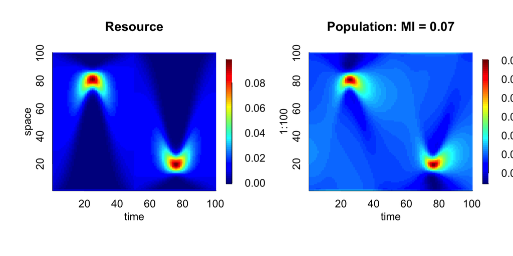

### Questions that this model can answer:

Q1. What's the “best” parameter combination to maximize FE - how does that affect Migratoriness and Cohesiveness - under various resource scenarios.

Q2. Can migration emerge from a non-migratory initial condition?

Q3. As conditions CHANGE, how resilient is the population at various Diffusion, Advection, Cohesion, Memory values?

- spatial drift
- temporal drift
- increased variability

[figure not shown]